# Methylation preprocess

Tereza Lausová

2024-01-25

## Load files

```r
basenames <- list.files(here("data/idat/")) %>%
  str_split("_") %>%
  map(~ .[c(1:3)]) %>%
  map(~ str_flatten(., collapse = "_")) %>%
  unique() %>%
  unlist()
```

This fails:

```r
rgsets <-
  read.metharray(file.path(here("data/idat/"), basenames), force = TRUE)
```

So I took the file sizes it outputted to console and saved it to a file:

```r
array_type <- read_csv(here("data/array_types.csv"))
basenames_450k <-
  array_type$filename[array_type$array == "IlluminaHumanMethylation450k"]
basenames_epic <-
  array_type$filename[array_type$array == "IlluminaHumanMethylationEPIC"]

rgsets_450k <- read.metharray(file.path(here("data/idat/"), basenames_450k),
  force = TRUE
)
rgsets_epic <- read.metharray(file.path(here("data/idat/"), basenames_epic),
  force = TRUE
)

rgsets_combined <- minfi::combineArrays(rgsets_450k, rgsets_epic)
```

```
## [convertArray] Casting as IlluminaHumanMethylation450k
```

```r
rm(rgsets_450k)
rm(rgsets_epic)
gc()
```

```
##             used   (Mb) gc trigger   (Mb)   max used   (Mb)
## Ncells  13653275  729.2   25461864 1359.9   15261925  815.1
## Vcells 185954430 1418.8  941057828 7179.8 1176096513 8973.0
```

## Preprocess according to the paper

*“The raw DNA methylation intensity data files (IDAT) were processed with the minfi package (23). We performed noob (Normal-exponential convolution using out-of-band probes) background correction (24) and dye bias correction using the minfi package (v 1.36.0) (23).”*

*“A detection p-value also accompanies each data point and compares the signal intensity difference between the analytical probes and a set of negative control probes on the array. Any data point with a corresponding p-value greater than 1E-4 is deemed not to be statistically significantly different from background and was thus masked as “NA”.”*

```r
## preprocess Noob and dye bias correction
mset <- preprocessNoob(rgsets_combined, dyeCorr = TRUE)
## betas
betas <- minfi::getBeta(mset)

## detection Pval
pval <- minfi::detectionP(rgsets_combined)
sum(pval > 1e-4)
```

```
## [1] 312661
```

```r
betas[] <- replace(x = betas, list = which(pval > 1e-4), values = NA)
```

## Checking out missing values

```r
annot <- read.xlsx(here("data/can-23-2093_table_s1_suppst1.xlsx"))
annot_files <- read_csv(here("data/annotation_primary_recurrence.csv"),
  col_names = FALSE
) %>%
  mutate("glassID" = str_remove_all(X4, "[\\[|\\]]")) %>%
  mutate("sample" = X1) %>%
  select(glassID, sample)
array_type <- array_type %>%
  mutate("sample" = str_extract(filename, "^GSM[:digit:]*(?=_)"))
annot_full <- annot_files %>%
  left_join(array_type) %>%
  left_join(annot)
```

I decided to do dimensionality reduction for the visualisation of missing values, because the 50K+ rows with missing values are too much for any (p)heatmap. Let’s see if there are any clusters. I would hope that it’s more or less just a blob of points.

```r
missing <- is.na(betas)
miss_rows <- rowCounts(is.na(betas))
miss_cols <- colCounts(is.na(betas))

missing_betas <- betas[which(miss_rows > 0), which(miss_cols > 0)]
missing_betas <- ifelse(is.na(missing_betas), 1, 0)

missing_umap <- umap(t(missing_betas))
mis_umap_tib <- tibble(
  "UMAP_1" = missing_umap$layout[, 1],
  "UMAP_2" = missing_umap$layout[, 2],
  "filename" = rownames(missing_umap$layout)
)
mis_umap_tib <- left_join(mis_umap_tib, annot_full)
```

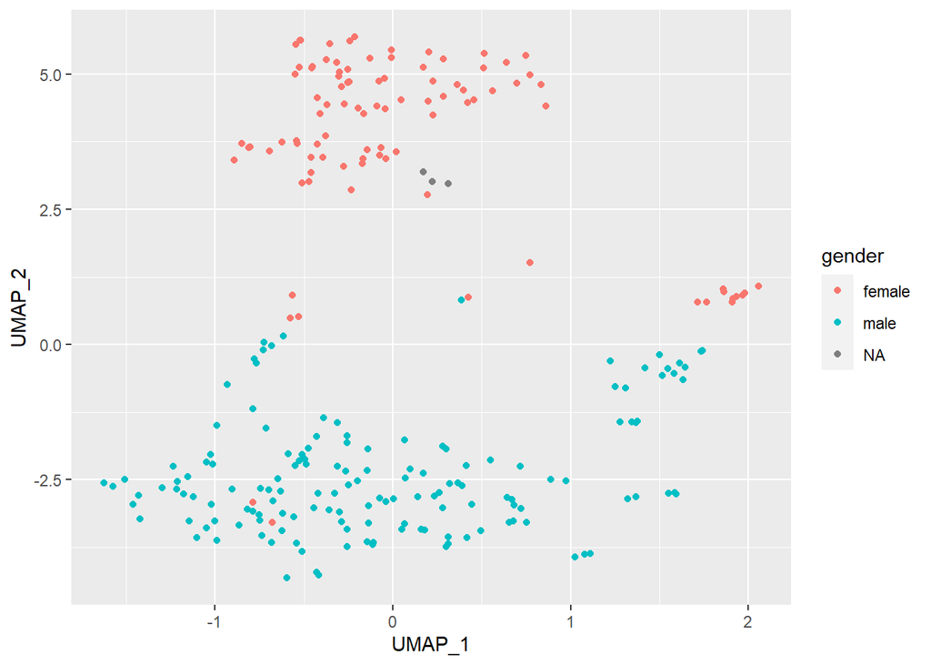

```r
ggplot(mis_umap_tib) +
  geom_point(aes(x = UMAP_1, y = UMAP_2, color = gender))
```

Well, if the paper methods are to be followed as-is, they did not remove sex chromosomes. (Or crossreactive probes, for that matter.) I really hope they removed them for the actual analysis.

```r
data(IlluminaHumanMethylation450kanno.ilmn12.hg19)
sexprobes <- rownames(Locations)[which(Locations$chr %in% c("chrX", "chrY"))]

betas_sexdropped <- betas[!which(rownames(betas) %in% sexprobes), ]
```

Repeating the missing values inquiry (yes, shamelessly copy-pasting code.)

```r
missing <- is.na(betas_sexdropped)
miss_rows <- rowCounts(is.na(betas_sexdropped))
miss_cols <- colCounts(is.na(betas_sexdropped))

missing_betas <- betas_sexdropped[which(miss_rows > 0), which(miss_cols > 0)]
missing_betas <- ifelse(is.na(missing_betas), 1, 0)
sum(is.na(missing_betas))
```

```
## [1] 0
```

## Save

```r
write_rds(
  betas,
  here("out/rds/2023-01-25-betas-preprocessed-sexchromincl.RDS")
)
write_rds(
  betas_sexdropped,
  here("out/rds/2023-01-25-betas-preprocessed-sexchromdropped.RDS")
)
```